# ARIMA-Bitcoin

Dado el análisis *descriptivo* de las características básicas de la serie de tiempo **Bitcoin**, que nos muestra el valor de cierre en bolsa para esta moneda digital en una ventana de tiempo de **5 años**, se usaran distintos modelos estadísticos para predecir el valor de cierre de Bitcoin en el futuro. Estos modelos seran evaluados por su capacidad predictiva.

Por lo tanto realizaremos una division (o split) de los datos en **entrenamiento** y **test** de manera tal que usaremos el $20\%$ de los datos para el conjunto de **test.**

```
[1] "Número de datos total: 1826"
```

```
[1] "Número de datos en el conjunto de entrena: 1460"
```

[output not shown]

# Modelo ARIMA para Bitcoin

Para este tipo de modelo la serie de tiempo puede ser *no estacionaria*, ademas si tiene tendencia esta se puede considerar estocastica o determinista y la serie debe tener presencia de al menos una **raiz unitaria**. Teniendo en cuenta estas consideraciones y el análisis *descriptivo* trabajaremos con la serie transformada.

[interactive chart not shown]

## Prueba de Raíz unitaria

Ahora vamos a verificar si la serie presenta una o varias raíces unitarias, con el fin de conocer cuántas diferencias vamos a necesitar para convertirla en estacionaria. Primero utilizamos un modelo automático autoregresivo generado por R para saber el orden del rezago mas alto para calcular el *estadistico de prueba.*

```
Call:
ar(x = lData_xts)

Coefficients:
     1
0.9972

Order selected 1  sigma^2 estimated as  0.00599
```

Vemos que se sugiere un valor de $k=1$

```
    Augmented Dickey-Fuller Test

data:  lData_xts
Dickey-Fuller = -1.8302, Lag order = 1, p-value = 0.6502
alternative hypothesis: stationary
```

```
###############################################
# Augmented Dickey-Fuller Test Unit Root Test #
###############################################

Test regression none


Call:
lm(formula = z.diff ~ z.lag.1 - 1 + z.diff.lag)

Residuals:
     Min       1Q   Median       3Q      Max
-0.49559 -0.01757  0.00037  0.02007  0.23564

Coefficients:
             Estimate Std. Error t value Pr(>|t|)
z.lag.1     0.0002226  0.0001101   2.021  0.04343 *
z.diff.lag -0.0616076  0.0233893  -2.634  0.00851 **
---
Signif. codes:  0 '***' 0.001 '**' 0.01 '*' 0.05 '.' 0.1 ' ' 1

Residual standard error: 0.04314 on 1822 degrees of freedom
Multiple R-squared:  0.005742,  Adjusted R-squared:  0.004651
F-statistic: 5.261 on 2 and 1822 DF,  p-value: 0.005268


Value of test-statistic is: 2.021

Critical values for test statistics:
      1pct  5pct 10pct
tau1 -2.58 -1.95 -1.62
```

Basados en la prueba de raíz unitaria de Dickey-Fuller, podemos observar que nuestra serie tiene presencia de al menos una raíz unitaria. Además, vemos que el último coeficiente es significativo al $5\%$, lo que da mayor potencia al test. Por lo tanto, concluimos que la serie es no estacionaria. Así la diferenciaremos una vez y repetimos el proceso.

[interactive chart not shown]

Vemos que la serie con la primera diferencia no muestra *tendencia,* y parece denotarse un valor extremo en el año $2020$. Continuaremos con un *test de Dickey-Fuller* para la serie diferenciada.

```
Call:
ar(x = dldata_xts)

Coefficients:
      1        2
-0.0592   0.0424

Order selected 2  sigma^2 estimated as  0.001857
```

El parámetro $k$ en esta ocasión es $2$.

```
    Augmented Dickey-Fuller Test

data:  dldata_xts
Dickey-Fuller = -24.386, Lag order = 2, p-value = 0.01
alternative hypothesis: stationary
```

[output not shown]

Notamos que el *p-valor* de la prueba es menor a $\alpha = 0.05$ con ello rechazamos la $H_0$ del *test de Dickey-Fuller* así la serie diferencia no presenta raíces unitarias, aunque esto **no necesariamente** implica que está serie sea estacionaria nos vale para continuar con el procedimiento.

## Identificación de los modelos

pasaremos a conocer los valores para $p$ y $q$ en el modelo para ello usaremos el **conjunto de** **entrenamiento.**

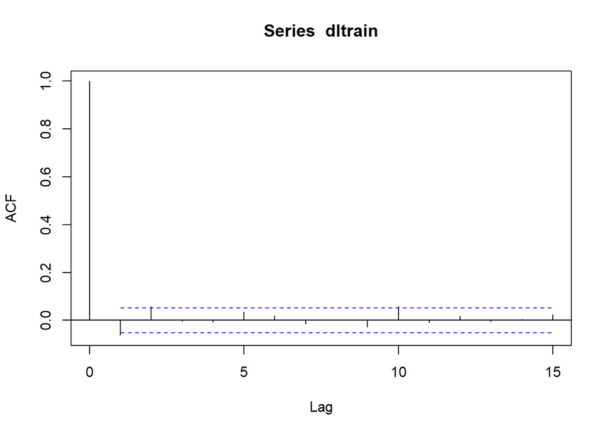

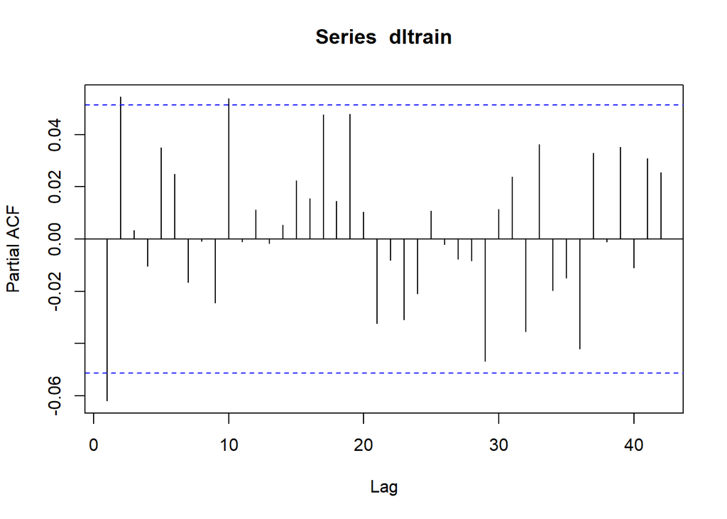

Vemos que dado el **acf** $q$ puede ser un de orden $1$ y del **pacf** tenemos que $p$ puede ser de orden $1,2$ o $10$. Con esto tenemos las siguientes posibilidades $ARIMA(0,1,1), ARIMA(1,1,0), ARIMA(2,1,0), ARIMA(10,1,0)$

## Modelos posibles

Debido a que encontramos varios modelos **ARIMA** posibles, usaremos los *criterios de información* para poder seleccionar el mejor de ellos. Esto nos permitirá **no** usar el **conjunto de test** por ahora para poder comparar con otro tipo de modelo sobre estos mismos datos en su *capacidad predictiva*, tal como se indicó al inicio. Los *criterios de información* se utilizan para seleccionar el modelo **ARIMA** con los parámetros que mejor se **ajustan** a los datos.

### Modelo ARIMA(0,1,1)

```r
ARIMA011 <- forecast::Arima(train, order = c(0,1,1), lambda = 0,
                            include.drift = TRUE)
lmtest::coeftest(ARIMA011)
```

```
z test of coefficients:

        Estimate Std. Error z value Pr(>|z|)
ma1   -0.0557078  0.0247607 -2.2498  0.02446 *
drift  0.0023054  0.0010709  2.1528  0.03133 *
---
Signif. codes:  0 '***' 0.001 '**' 0.01 '*' 0.05 '.' 0.1 ' ' 1
```

Vemos que el parámetro es significante al $5\%$, así $ARIMA(0,1,1)$ pasa a la evaluación.

### Modelo ARIMA(1,1,0)

```r
ARIMA110 <- forecast::Arima(train, order = c(1,1,0), lambda = 0,
                            include.drift = TRUE)
lmtest::coeftest(ARIMA110)
```

```
z test of coefficients:

        Estimate Std. Error z value Pr(>|z|)
ar1   -0.0619384  0.0261359 -2.3699  0.01780 *
drift  0.0023038  0.0010677  2.1577  0.03095 *
---
Signif. codes:  0 '***' 0.001 '**' 0.01 '*' 0.05 '.' 0.1 ' ' 1
```

Notamos que el pará¡metro es significante al $5\%$, así $ARIMA(1,1,0)$ pasa a evaluación.

### Modelo ARIMA(2,1,0)

```r
ARIMA210 <- forecast::Arima(train, order = c(2,1,0), lambda = 0,
                             include.drift = TRUE)
lmtest::coeftest(ARIMA210)
```

```
z test of coefficients:

        Estimate Std. Error z value Pr(>|z|)
ar1   -0.0585756  0.0261471 -2.2402  0.02508 *
ar2    0.0542763  0.0261384  2.0765  0.03785 *
drift  0.0023007  0.0011272  2.0411  0.04124 *
---
Signif. codes:  0 '***' 0.001 '**' 0.01 '*' 0.05 '.' 0.1 ' ' 1
```

Vemos que los parámetros son significantes al $5\%$, así $ARIMA(2,1,0)$ pasa a evaluación.

### Modelo ARIMA(10,1,0)

```r
ARIMA1010 <- forecast::Arima(train, order = c(10,1,0), lambda = 0,
                             include.drift = TRUE)
lmtest::coeftest(ARIMA1010)
```

```
z test of coefficients:

        Estimate Std. Error z value Pr(>|z|)
ar1   -0.0575273  0.0261437 -2.2004  0.02778 *
ar2    0.0554122  0.0261771  2.1168  0.03428 *
ar3    0.0016463  0.0262374  0.0627  0.94997
ar4   -0.0096182  0.0263053 -0.3656  0.71463
ar5    0.0357638  0.0263768  1.3559  0.17514
ar6    0.0250219  0.0263874  0.9483  0.34300
ar7   -0.0154919  0.0263868 -0.5871  0.55713
ar8   -0.0057024  0.0263834 -0.2161  0.82888
ar9   -0.0212168  0.0263384 -0.8055  0.42051
ar10   0.0549603  0.0263786  2.0835  0.03720 *
drift  0.0023014  0.0012045  1.9107  0.05604 .
---
Signif. codes:  0 '***' 0.001 '**' 0.01 '*' 0.05 '.' 0.1 ' ' 1
```

Notamos que se requiere refinar el modelo debido a que encontramos varios coeficientes que tienen un *p-valor* mayor que el nivel de significancia $α=0.05$, pero el último sí es significativo al $5%$. Por lo tanto, empezaremos el refinamiento fijando en $0$ aquellos $p$ más grandes no significativos bajo un $α=0.05$. De esta manera, tendremos un modelo donde sean significativos todos sus parámetros.

```r
ARIMA1010 <- forecast::Arima(train, order = c(10,1,0), lambda = 0,
                             include.drift = TRUE,
                             fixed = c(NA,NA,0,0,0,0,0,0,0,NA,
                                       0))
lmtest::coeftest(ARIMA1010)
```

```
z test of coefficients:

      Estimate Std. Error z value Pr(>|z|)
ar1  -0.054277   0.026103 -2.0794  0.03758 *
ar2   0.056882   0.026092  2.1801  0.02925 *
ar10  0.059603   0.026289  2.2672  0.02338 *
---
Signif. codes:  0 '***' 0.001 '**' 0.01 '*' 0.05 '.' 0.1 ' ' 1
```

Vemos que para $ARIMA(10,1,0)$ solo quedaron tres parámetros y sigue para evaluación.

### Modelo ARIMA(1,1,1)

```r
ARIMA111 <- forecast::Arima(train, order = c(1,1,1), lambda = 0,
                            include.drift = TRUE)
lmtest::coeftest(ARIMA111)
```

```
z test of coefficients:

        Estimate Std. Error z value Pr(>|z|)
ar1   -0.5077576  0.2178783 -2.3305  0.01978 *
ma1    0.4425865  0.2270284  1.9495  0.05124 .
drift  0.0022930  0.0010838  2.1157  0.03437 *
---
Signif. codes:  0 '***' 0.001 '**' 0.01 '*' 0.05 '.' 0.1 ' ' 1
```

Vemos que dado el $\alpha$ que se maneja entonces el parámetro asociado al *polinomio promedios móviles* es insignificante por tanto volvemos a un $ARIMA(1,1,0)$.

### Modelo ARIMA(2,1,1)

```r
ARIMA211 <- forecast::Arima(train, order = c(2,1,1), lambda = 0,
                             include.drift = TRUE)
lmtest::coeftest(ARIMA211)
```

```
z test of coefficients:

        Estimate Std. Error z value Pr(>|z|)
ar1    0.0409134  0.4870006  0.0840  0.93305
ar2    0.0601599  0.0368525  1.6325  0.10258
ma1   -0.0998918  0.4879808 -0.2047  0.83780
drift  0.0022891  0.0011335  2.0194  0.04344 *
---
Signif. codes:  0 '***' 0.001 '**' 0.01 '*' 0.05 '.' 0.1 ' ' 1
```

Vemos que ninguno de los parámetros del *polinomio auto-regresivo* o del de *promedios móviles* es significante, así descartamos este modelo.

### Modelo ARIMA(10,1,1)

```r
ARIMA1011 <- forecast::Arima(train, order = c(10,1,1), lambda = 0,
                             include.drift = TRUE)
lmtest::coeftest(ARIMA1011)
```

```
z test of coefficients:

        Estimate Std. Error z value Pr(>|z|)
ar1   -0.1662121  0.6216172 -0.2674  0.78917
ar2    0.0490160  0.0451201  1.0863  0.27733
ar3    0.0076411  0.0433615  0.1762  0.86012
ar4   -0.0094893  0.0266207 -0.3565  0.72149
ar5    0.0348610  0.0271848  1.2824  0.19971
ar6    0.0291048  0.0354071  0.8220  0.41107
ar7   -0.0128381  0.0307213 -0.4179  0.67603
ar8   -0.0073477  0.0282389 -0.2602  0.79471
ar9   -0.0215151  0.0267345 -0.8048  0.42095
ar10   0.0518371  0.0336126  1.5422  0.12303
ma1    0.1088513  0.6226759  0.1748  0.86123
drift  0.0022987  0.0011974  1.9198  0.05489 .
---
Signif. codes:  0 '***' 0.001 '**' 0.01 '*' 0.05 '.' 0.1 ' ' 1
```

Notamos que ninguno de los parámetros es significante entonces descartamos por completo este modelo.

### Selección del modelo

Miraremos los valores guardados para cada uno de los $4$ modelos que tenemos ajustamos en la parte anterior

**Criterio AIC**

|  | ARIMA(0,1,1) | ARIMA(1,1,0) | ARIMA(2,1,0) | ARIMA(10,1,0) |
| --- | --- | --- | --- | --- |
| AIC | -5014.722 | -5015.287 | -5017.592 | -5018.563 |

vemos que para el AIC es el modelo $ARIMA(10,1,0)$

**Criterio BIC**

|  | ARIMA(0,1,1) | ARIMA(1,1,0) | ARIMA(2,1,0) | ARIMA(10,1,0) |
| --- | --- | --- | --- | --- |
| BIC | -4998.865 | -4999.431 | -4996.45 | -4997.42 |

vemos que para el BIC es el modelo $ARIMA(1,1,0)$

## Comprobación de Supuestos

Para cada modelo seleccionado como mejor dado cada uno de los *criterios*, realizaremos la *comprobación de supuestos* necesarios para un modelo de la familia **ARIMA**, de estacionariedad, normalidad, homocedasticidad y ausencia de autocorrelación

### Modelo ARIMA(1,1,0)

Realizaremos para el modelo destacado por el *BIC* la comprobación de supuestos.

[interactive chart not shown]

Vemos que potencialmente se tiene un valor atípico, como ya habíamos expresado anteriormente. Por ende, procederemos a realizar la detección de dichos valores y, si es posible, un manejo para los mismos.

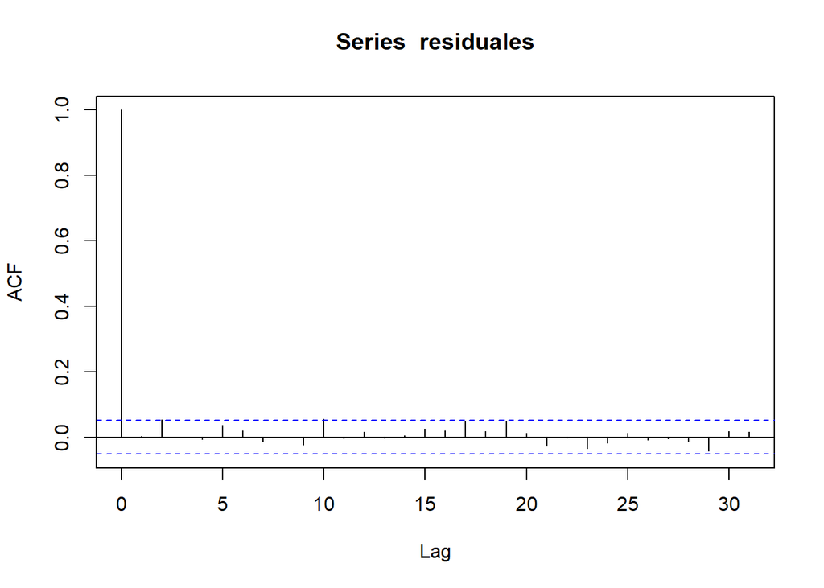

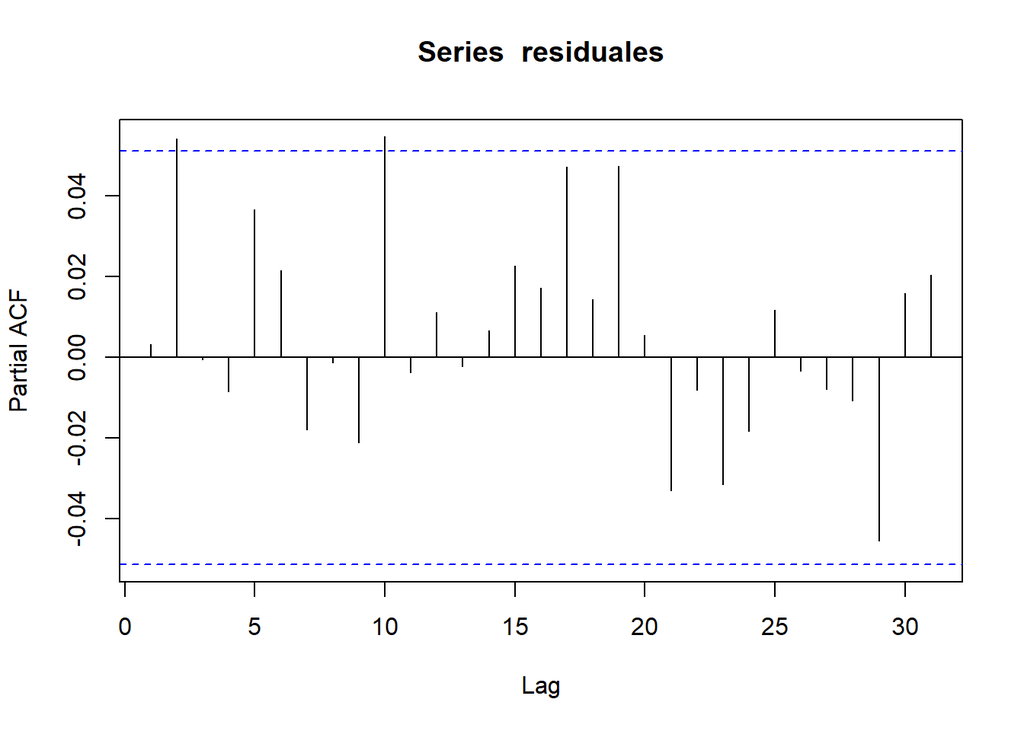

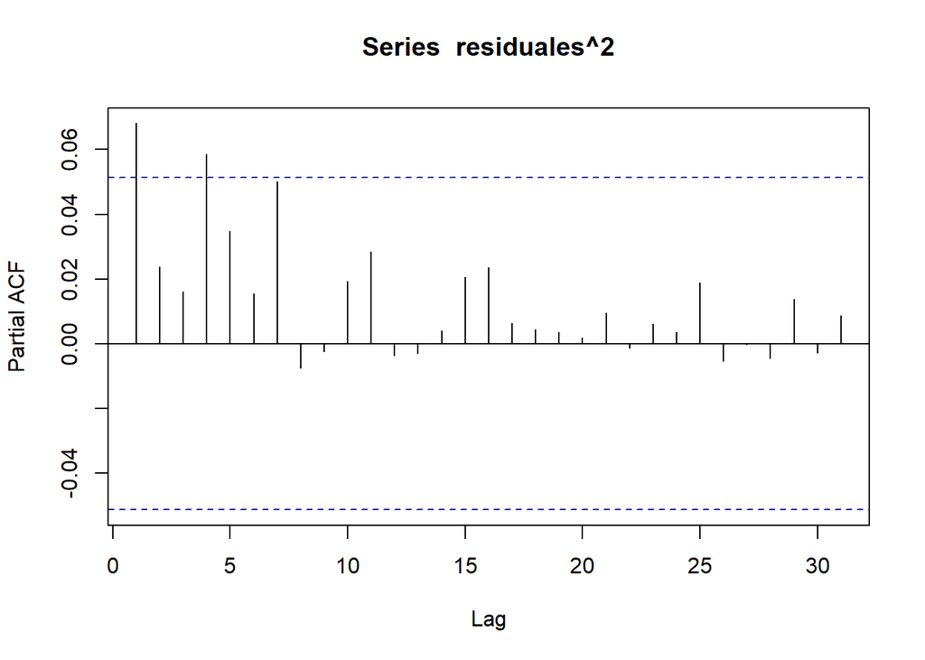

Una revisión de los residuales al cuadrado muestra que la auto-correlación del primer y del cuarto rezago crece, dando un indicador de que el modelo no captura bien la variabilidad de los presentada en los datos.

#### Detección de Valores atípicos

Se considerara modelar los valores atípicos encontrados en un **análisis de intervención.**

| IO | AO | LS | TC | SLS |
| --- | --- | --- | --- | --- |
| 0 | 37 | 51 | 22 | 0 |

```
[1] "Número de datos atípicos: 110"
```

Vemos que se encuentran automaticamente $110$ valores atipicos de tipo aditivo (AO), cambio de nivel (LS) y cambio transitorio (TC) que representan un $7,5\%$ de el entrenamiento. aun así consideraremos si se pueden modelar dichos valores.

```r
#intentamos tener encuenta el efecto
xreg <-  tsoutliers::outliers.effects(outliers, length(train))
#head(xreg)
```

Volveremos a estimar el modelo teniendo en cuenta la influencia de estos valores atípicos.

```r
ARIMA110_out <- forecast::Arima(train, order = c(1,1,0), lambda = 0,
                            include.drift = TRUE, xreg=xreg)
```

```
          Estimate   Std. Error    z value     Pr(>|z|)
ar1   -0.026798922 0.0278399814 -0.9626056 3.357455e-01
drift  0.003002067 0.0007329313  4.0959725 4.203998e-05
AO4    0.076786197 0.0280087957  2.7415030 6.115880e-03
AO10   0.013587466 0.0261154752  0.5202841 6.028656e-01
AO80   0.070151435 0.0200681888  3.4956535 4.729023e-04
AO157  0.068317481 0.0200595176  3.4057390 6.598524e-04
```

```
          Estimate Std. Error   z value     Pr(>|z|)
TC927  -0.15687030 0.03926183 -3.995491 6.456032e-05
TC929   0.06882787 0.02627707  2.619313 8.810694e-03
TC1026 -0.08117942 0.02740988 -2.961685 3.059610e-03
TC1223  0.08740696 0.02598568  3.363659 7.691651e-04
TC1226 -0.08025761 0.02602342 -3.084053 2.042011e-03
TC1426 -0.08983189 0.02594736 -3.462081 5.360149e-04
```

En el análisis de los valores atípicos, observamos que el modelo ajustado toma varios valores como **no** significantes entre los que se habían anunciado para trabajar con este tipo de datos. Por lo tanto, **no** modelaremos estos valores atípicos.

#### Análisis de residuales

```
    Jarque Bera Test

data:  residuales
X-squared = 12256, df = 2, p-value < 2.2e-16
```

El *test de Jarque-Bera* dado su *p-valor rechazamos* $H_0$ por tanto los residuales **no** presentan una distribución normal, así el supuesto de normalidad no se tiene en este modelo.

```
[1] 365
```

```
[1] 38.20995
```

```
    Box-Ljung test

data:  residuales
X-squared = 37.389, df = 37, p-value = 0.4512
```

El *test de Box-Ljung* dado su *p-valor no rechazamos* $H_0$ por tanto los residuales son no auto-correlacionados. Cumpliendo el supuesto de no *auto-correlación.*

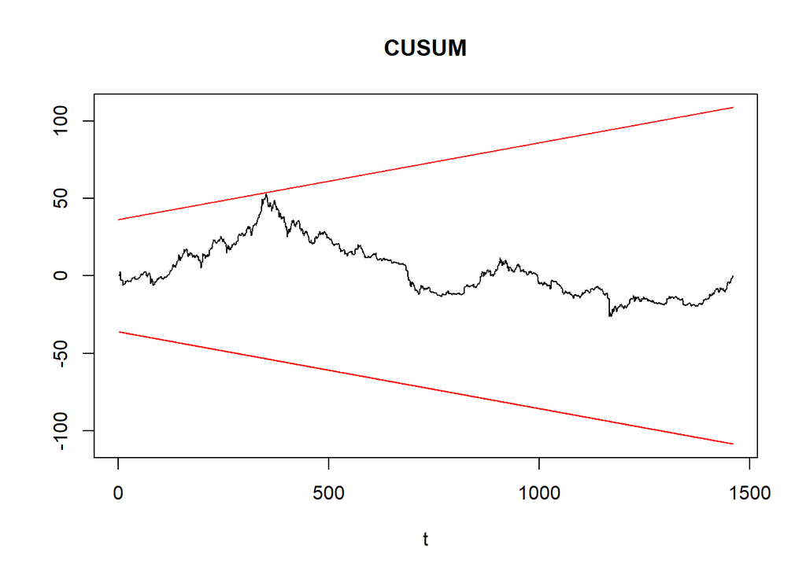

Podemos observar que los parámetros muestran estabilidad pues nunca sobrepasan las bandas.

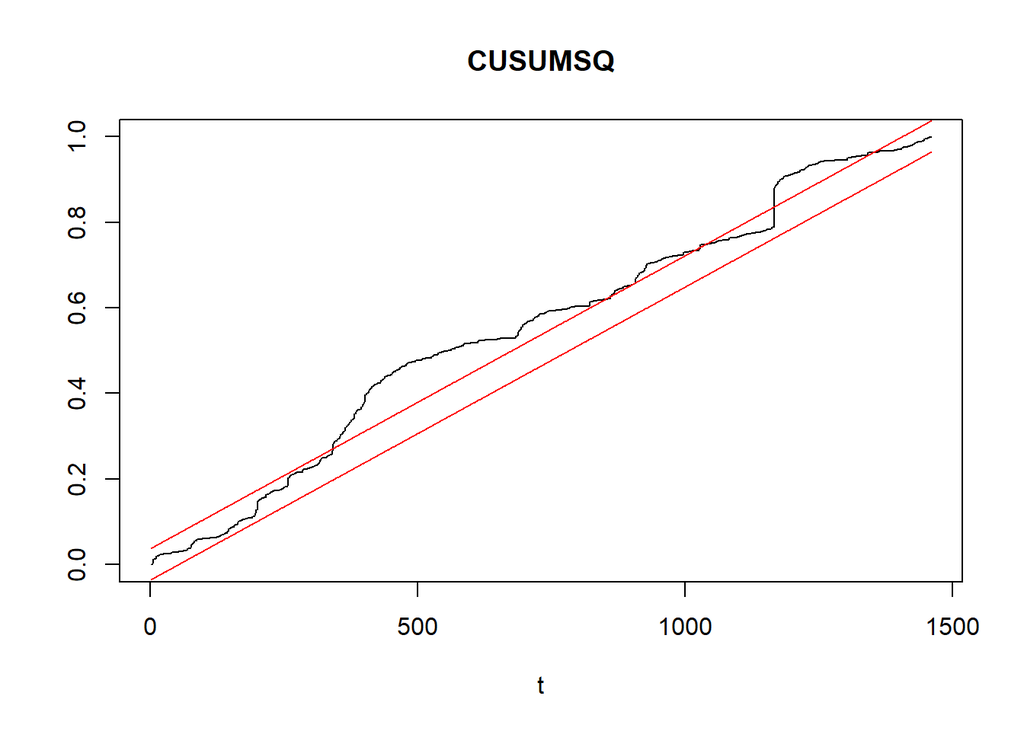

Notamos que para el caso de la *cumsum cuadrado* no se presenta estabilidad en los valores, lo nos muestra que el modelo no captura por completo la variabilidad del ruido.

### Modelo ARIMA(10,1,0)

Realizaremos para el modelo destacado por el *AIC* la comprobación de supuestos.

[interactive chart not shown]

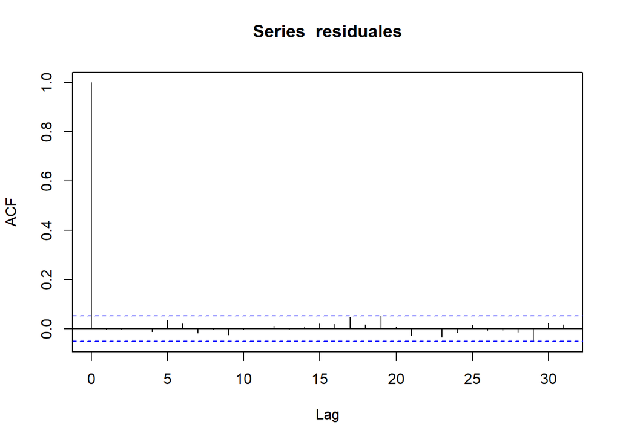

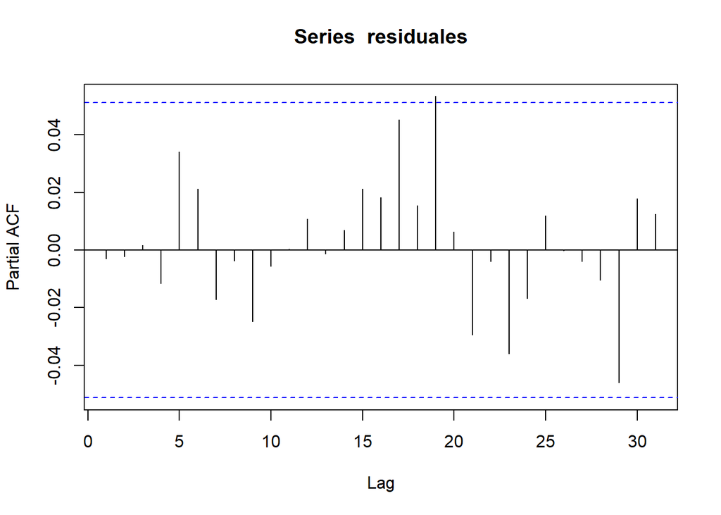

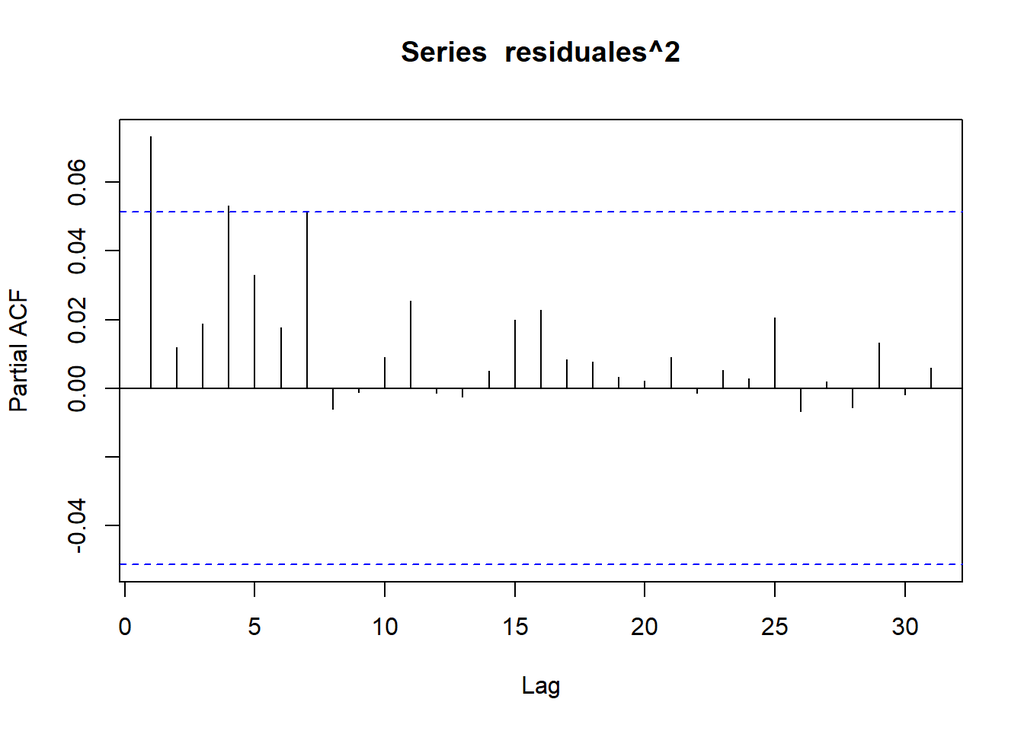

Vemos un comportamiento similar al del modelo anterior, así continuaremos como antes.

#### Detección de Valores atípicos

| IO | AO | LS | TC | SLS |
| --- | --- | --- | --- | --- |
| 0 | 36 | 50 | 22 | 0 |

```
[1] "Número de datos atípicos: 108"
```

Notamos un comportamiento nuevamente similar, por ende **no** modelaremos los valores atípicos.

#### Análisis de residuales

```
    Jarque Bera Test

data:  residuales
X-squared = 12841, df = 2, p-value < 2.2e-16
```

El *test de Jarque-Bera* dado su *p-valor rechazamos* $H_0$ por tanto los residuales **no** presentan una distribución normal, así el supuesto de normalidad no se tiene en este modelo.

```
[1] 365
```

```
[1] 38.20995
```

```
    Box-Ljung test

data:  residuales
X-squared = 28.908, df = 35, p-value = 0.7562
```

El *test de Box-Ljung* dado su *p-valor no rechazamos* $H_0$ por tanto los residuales son no auto-correlacionados. Cumpliendo el supuesto de no *auto-correlación.*

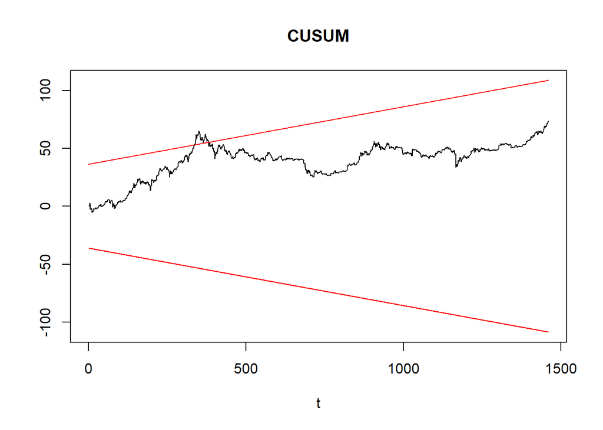

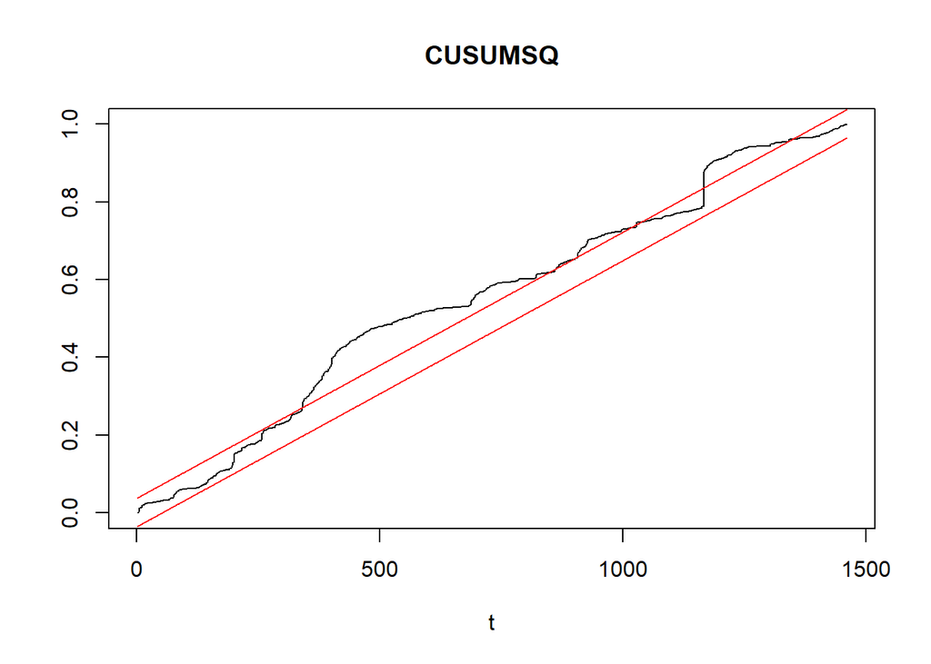

Podemos observar que para *cumsum* y *cusum cuadrado* **no** se tiene estabilidad en el modelo siendo peor que el anterior modelo.

Con todo lo anteriormente presentado concluimos que:

- Posiblemente el supuesto de normalidad no se cumple por que los modelo no capturan bien la variabilidad presentada en los datos, se sugiere modelos de la familia **GARCH**.
- Cómo, el objetivo es comprar por la capacidad predictiva distintos modelos obtendremos una estadística para el **ARIMA(1,1,0)**, teniendo en cuenta la sugerencia dada en el punto anterior.

## Capacidad predictiva

### Modelo ARIMA(1,1,0)

Usaremos **rolling** una técnica que nos permitirá tener predicciones un paso adelante para el **conjunto de prueba,** está se realizara sin *reparámetrización.*

Veremos las primeras $10$ predicciones con sus respectivos orígenes.

| origin1460 | origin1461 | origin1462 | origin1463 | origin1464 | origin1465 | origin1466 | origin1467 | origin1468 | origin1469 |
| --- | --- | --- | --- | --- | --- | --- | --- | --- | --- |
| 27415.24 | 28855.82 | 29056.92 | 29449.37 | 32116.91 | 33127.73 | 32151.85 | 33997.02 | 36771.2 | 39456 |

Cómo métrica de comparación usaremos el **RMSE** para poder compara entre distintos modelos.

```
      h1
1927.254
```

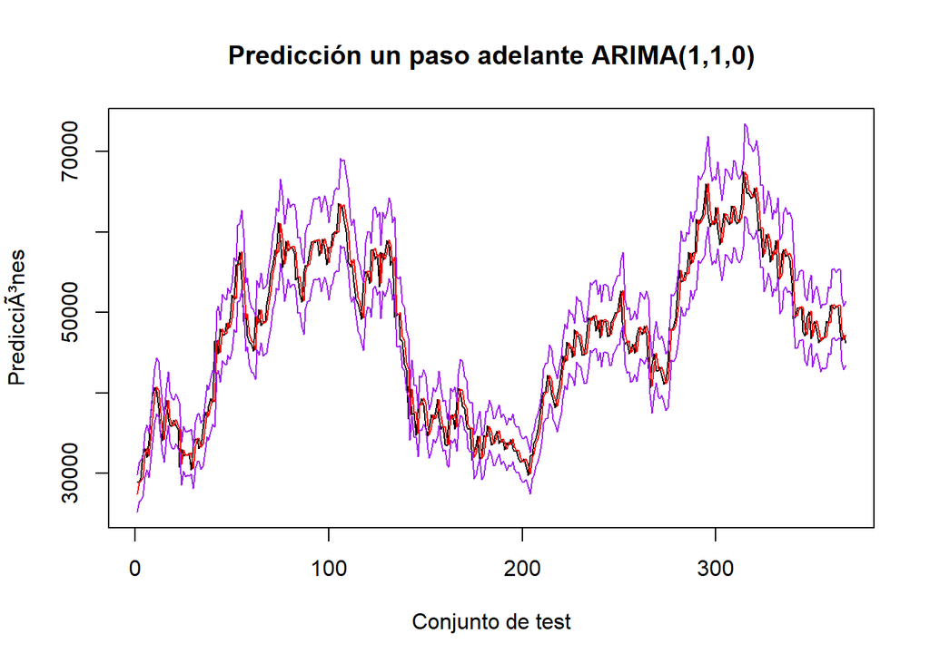

Gráfico nos permite ver las *predicciones* en color **rojo,** para el conjunto de prueba y las bandas de un intervalo de confianza al $95\%$ de color **morado.**

## Pronostico final tiempo no visto un paso adelante

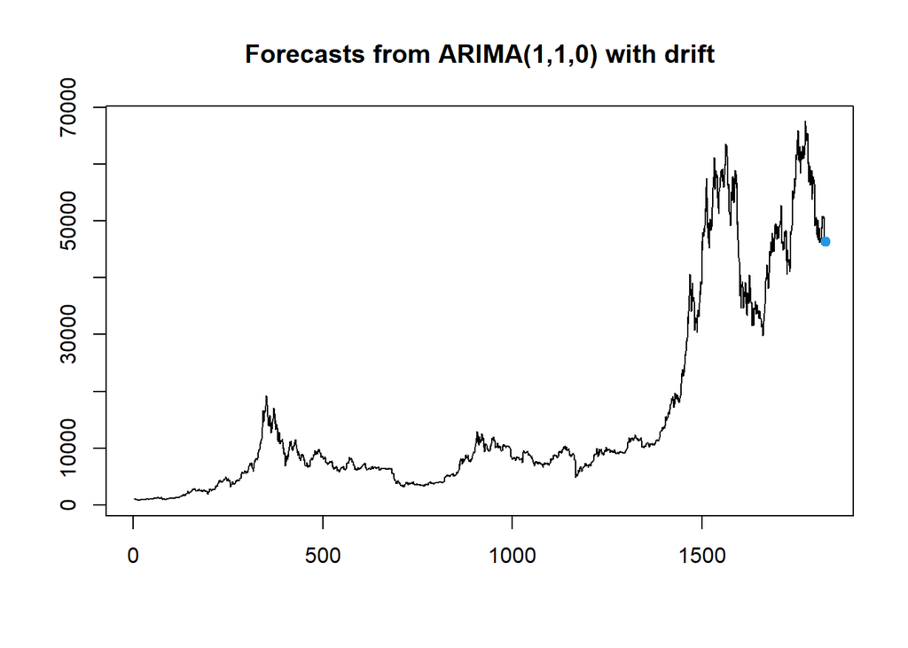

## Referencias

https://www.machinelearningplus.com/time-series/augmented-dickey-fuller-test/

https://medium.com/@cmukesh8688/why-is-augmented-dickey-fuller-test-adf-test-so-important-in-time-series-analysis-6fc97c6be2f0#:~:text=So%20we%20can%20say%20second,on%20ARIMA%20model%20for%20forecasting%20.